title: “hw4_Darshana_Daga” author: “Darshana” date: “5/2/2021”

#### Question1

#### Reading data in and prepping the data

```r
options(stringsAsFactors = TRUE)
setwd('C:\\Users\\darsh\\OneDrive\\Spring Quarter\\Predictive Analytics\\Assignment 4')
options(stringsAsFactors = TRUE)    #need to run this twice
dat <- read.csv("hw4_bike_share_day.csv")
dat1 <- dat
dat1$season <- as.factor(dat1$season)
dat1$yr <- as.factor(dat1$yr)
dat1$mnth <- as.factor(dat1$mnth)
dat1$weekday <- as.factor(dat1$weekday)
dat1$weathersit <- as.factor(dat1$weathersit)
#str(dat1)

timetr <- data.frame(1:731)
timetrsq <- timetr^2

dat1 <- cbind(dat1, timetr, timetrsq)

library(dplyr)
dat1<-dat1 %>% rename(timetr = names(.)[15])
dat1<-dat1 %>% rename(timetrsq = names(.)[16])

names(dat)
```

```
##  [1] "dayID"      "dteday"     "season"     "yr"         "mnth"
##  [6] "holiday"    "weekday"    "workday"    "weathersit" "temp"
## [11] "atemp"      "hum"        "windspeed"  "cnt"
```

```r
names(dat1)
```

```
##  [1] "dayID"      "dteday"     "season"     "yr"         "mnth"
##  [6] "holiday"    "weekday"    "workday"    "weathersit" "temp"
## [11] "atemp"      "hum"        "windspeed"  "cnt"        "timetr"
## [16] "timetrsq"
```

The new & transformed variables are;

1. Season
2. Year (yr)
3. Month (mnth)
4. Weekday (weekday)
5. Weather (weathersit)
6. Timetr
7. Timetsrq

#### Question2

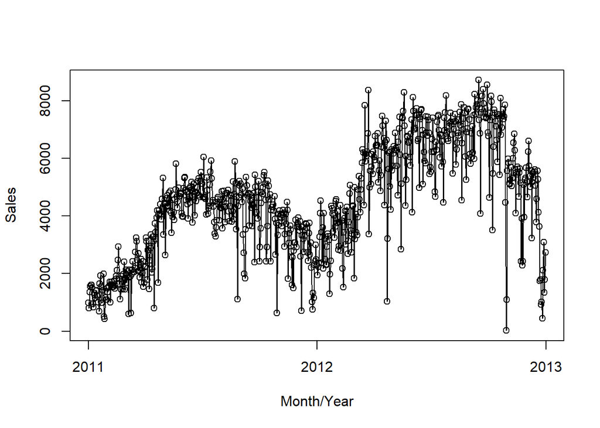

```r
dat1$dteday <- as.Date(dat1$dteday, format = "%m/%d/%Y")

plot(dat1$dteday, dat1$cnt, xlab = "Month/Year",
     ylab = "Sales")
lines(dat1$dteday, dat1$cnt, type = "l")
```

Post converting the date variable as date, and plotting the sales over time, I noticed trends in data which seems to be influenced by, months. There is dip in sales around October may be because less people are going to work during holiday season, as well as it gets cold during winter reducing the number of riders, where as during mid of the year when its summer the riders increase due to more pleasant weather.

#### Question3

```r
reg1 <- lm(cnt ~ timetr + timetrsq + mnth, data = dat1)
summary(reg1)
```

```
##
## Call:
## lm(formula = cnt ~ timetr + timetrsq + mnth, data = dat1)
##
## Residuals:
##     Min      1Q  Median      3Q     Max
## -6244.2  -446.1   143.8   648.5  3445.8
##
## Coefficients:
##               Estimate Std. Error t value Pr(>|t|)
## (Intercept)  8.243e+02  1.573e+02   5.242 2.09e-07 ***
## timetr       7.645e+00  7.635e-01  10.012  < 2e-16 ***
## timetrsq    -2.272e-03  1.003e-03  -2.266  0.02374 *
## mnth2        2.594e+02  1.925e+02   1.347  0.17838
## mnth3        1.123e+03  1.892e+02   5.937 4.53e-09 ***
## mnth4        1.721e+03  1.919e+02   8.968  < 2e-16 ***
## mnth5        2.394e+03  1.915e+02  12.501  < 2e-16 ***
## mnth6        2.630e+03  1.943e+02  13.537  < 2e-16 ***
## mnth7        2.239e+03  1.939e+02  11.543  < 2e-16 ***
## mnth8        2.158e+03  1.951e+02  11.063  < 2e-16 ***
## mnth9        2.086e+03  1.977e+02  10.551  < 2e-16 ***
## mnth10       1.349e+03  1.975e+02   6.832 1.79e-11 ***
## mnth11       2.315e+02  2.005e+02   1.155  0.24854
## mnth12      -7.733e+02  2.009e+02  -3.848  0.00013 ***
## ---
## Signif. codes:  0 '***' 0.001 '**' 0.01 '*' 0.05 '.' 0.1 ' ' 1
##
## Residual standard error: 1047 on 717 degrees of freedom
## Multiple R-squared:  0.713,  Adjusted R-squared:  0.7078
## F-statistic:   137 on 13 and 717 DF,  p-value: < 2.2e-16
```

```r
options(scipen=999)
yhat3 <- predict(reg1, dat1)
RSS3 <- sum((dat1$cnt - yhat3)^2)
MSE3 <- RSS3/(nrow(dat1)-13-1)
RMSE3 <- MSE3^0.5
RMSE3
```

```
## [1] 1047.201
```

The model fits okay with 0.713 r squared, which definitely can be improved. The time and time squared variables show significant relationship to the intercept but the degree of effect is relatively smaller compared to the intercept and other variable value, for example a unit increase in time squared only reduces the intercept by 0.002272 riders, which is negligible. The months do show a seasonality effect and its quite evident, the winter months from month 10 onward we see a dip in bikers and December being the worst month reducing riders by almost 773.27, where as the summer months are adding almost 2000-2600 riders.

#### Question4

```r
reg2 <- lm(cnt ~ timetr + timetrsq + season, data = dat1)
summary(reg2)
```

```
##
## Call:
## lm(formula = cnt ~ timetr + timetrsq + season, data = dat1)
##
## Residuals:
##     Min      1Q  Median      3Q     Max
## -5492.2  -579.2   138.1   687.4  4075.2
##
## Coefficients:
##                Estimate  Std. Error t value             Pr(>|t|)
## (Intercept)  887.419385  137.251301   6.466       0.000000000185 ***
## timetr         8.195803    0.847430   9.671 < 0.0000000000000002 ***
## timetrsq      -0.003835    0.001112  -3.447             0.000599 ***
## season2     2072.607016  124.632534  16.630 < 0.0000000000000002 ***
## season3     2215.702509  127.886173  17.326 < 0.0000000000000002 ***
## season4      863.223215  134.231586   6.431       0.000000000230 ***
## ---
## Signif. codes:  0 '***' 0.001 '**' 0.01 '*' 0.05 '.' 0.1 ' ' 1
##
## Residual standard error: 1171 on 725 degrees of freedom
## Multiple R-squared:  0.6372, Adjusted R-squared:  0.6347
## F-statistic: 254.7 on 5 and 725 DF,  p-value: < 0.00000000000000022
```

```r
yhat4 <- predict(reg2, dat1)
RSS4 <- sum((dat1$cnt - yhat4)^2)
MSE4 <- RSS4/(nrow(dat1)-5-1)
RMSE4 <- MSE4^0.5
RMSE4
```

```
## [1] 1170.851
```

#### Question5

```r
#install.packages("fpp2")
library(fpp2)
cntts <- ts(dat1[,14], frequency = 7)
cntts[1:10]
```

```
##  [1]  985  801 1349 1562 1600 1606 1510  959  822 1321
```

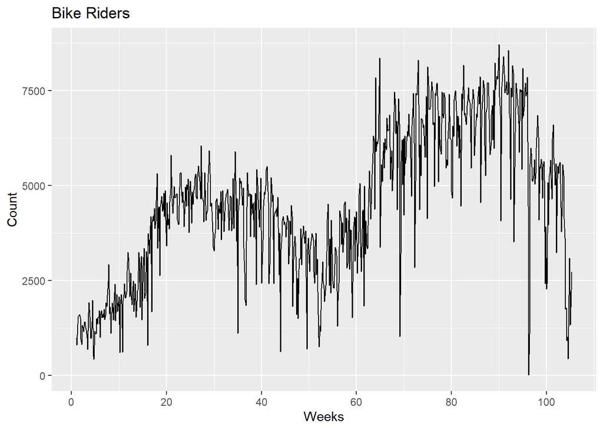

```r
autoplot(cntts) +
  ggtitle("Bike Riders") +
  ylab("Count") +
  xlab("Weeks")
```

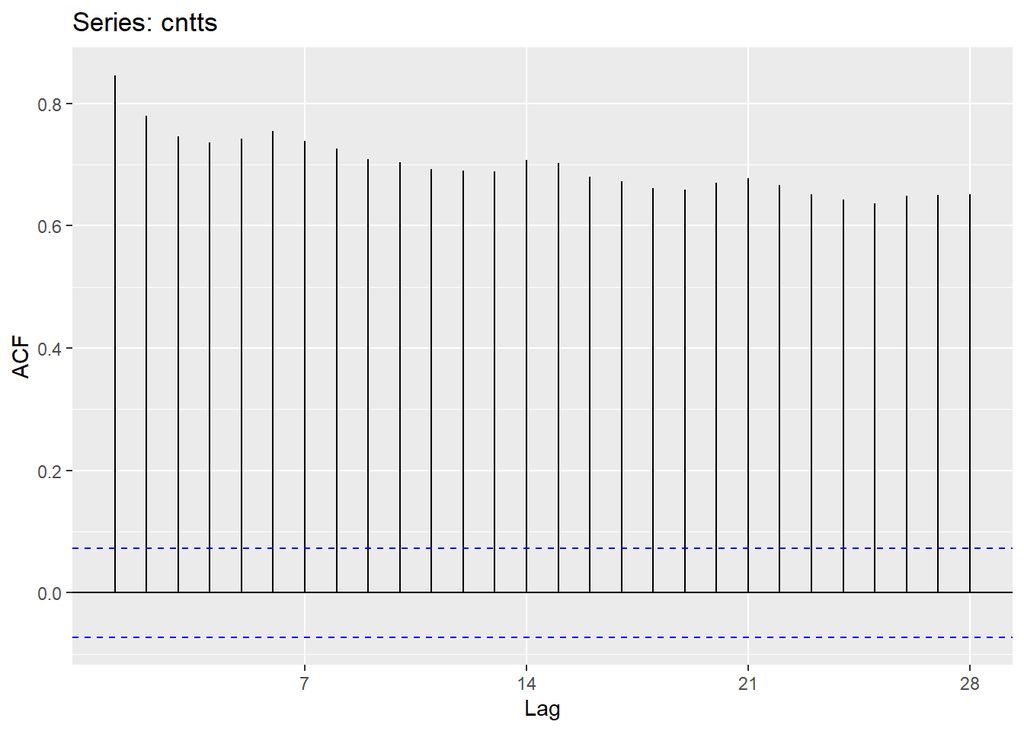

```r
ggAcf(cntts)
```

Regarding the autocorrelation plot, it seems all the days are highly correlated, and it does shows significance in the relationship.With weekends having a little higher correlation.

#### Question6

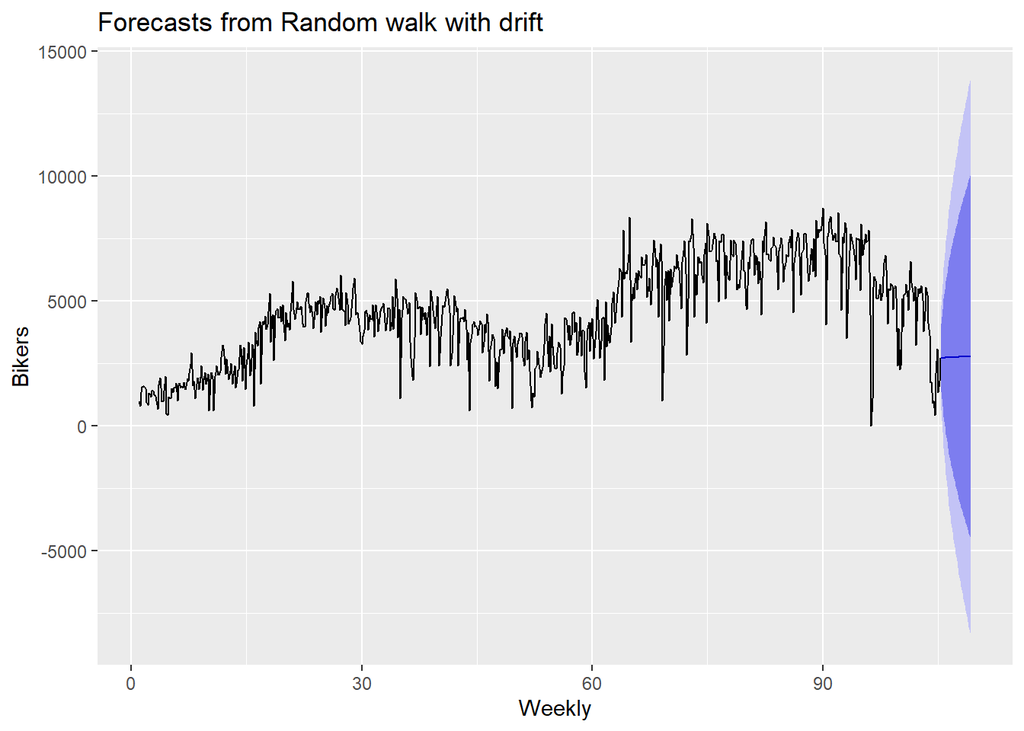

```r
f_nvd <- rwf(cntts, h = 28, drift = TRUE)

autoplot(f_nvd) +
  ylab("Bikers") +
  xlab("Weekly")
```

```r
res_nvd <- f_nvd$residuals
MSE_nvd <- mean((res_nvd[2:731])^2)
RMSE6.1 <- MSE_nvd^0.5
RMSE6.1
```

```
## [1] 1064.525
```

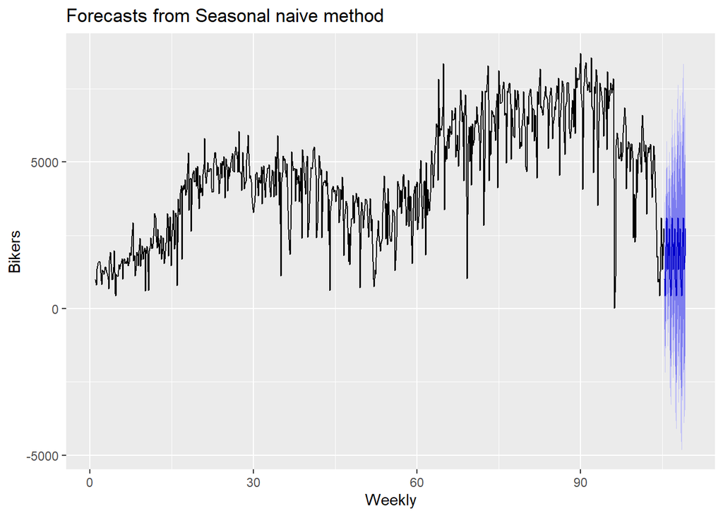

```r
f_snv <- snaive(cntts, h = 28)

autoplot(f_snv) +
  ylab("Bikers") +
  xlab("Weekly")
```

```r
res_snv <- f_snv$residuals
MSE_snv <- mean((res_snv[8:731])^2)
RMSE6.2 <- MSE_snv^0.5
RMSE6.2
```

```
## [1] 1341.106
```

```r
CV.nvd <- tsCV(cntts, rwf, drift=TRUE, h=28)
sqrt(mean(CV.nvd^2, na.rm=TRUE))
```

```
## [1] 1471.651
```

```r
RMSE6.3 <- sqrt(mean(residuals(rwf(cntts, drift=TRUE))^2, na.rm=TRUE))


CV.snv <- tsCV(cntts, snaive, h=28)
sqrt(mean(CV.snv^2, na.rm=TRUE))
```

```
## [1] 1404.557
```

```r
RMSE6.4 <- sqrt(mean(residuals(snaive(cntts))^2, na.rm=TRUE))
```

#### Question 7

```r
#calculating 5, 7, 11 and 17 time period moving average model
ma5 <- ma(cntts, 5)
ma7 <- ma(cntts, 7)
ma11 <- ma(cntts, 11)
ma17 <- ma(cntts, 17)

#calculating RMSE for the models above
RMSE7.1 = mean((cntts - na.omit(ma5))^2)^0.5
RMSE7.2 = mean((cntts - na.omit(ma7))^2)^0.5
RMSE7.3 = mean((cntts - na.omit(ma11))^2)^0.5
RMSE7.4 = mean((cntts - na.omit(ma17))^2)^0.5

RMSE7.1
```

```
## [1] 707.5955
```

```r
RMSE7.2
```

```
## [1] 794.9735
```

```r
RMSE7.3
```

```
## [1] 868.0221
```

```r
RMSE7.4
```

```
## [1] 879.68
```

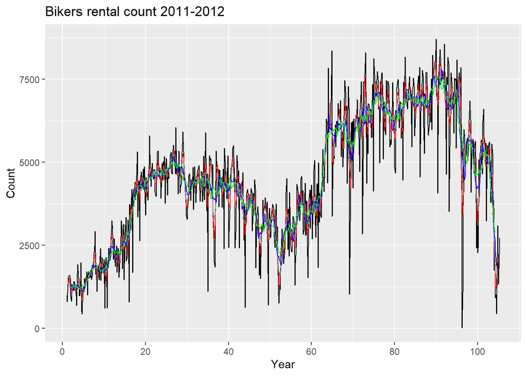

```r
#Plotting the 4 models in one graph
autoplot(cntts, series = "Actual Counts") +
  autolayer(ma5, series = "MA(5)") +
  autolayer(ma7, series = "MA(7)") +
  autolayer(ma11, series = "MA(11)") +
  autolayer(ma17, series = "MA(17)") +
  xlab("Year") + ylab("Count") +
  ggtitle("Bikers rental count 2011-2012") +
  scale_colour_manual(values =c("Actual Counts"="black","MA(5)"="red","MA(7)"="grey50","MA(11)"="blue","MA(17)"="green"),
breaks=c("Data", "5-MA","7-MA", "11-MA", "17-MA"))
```

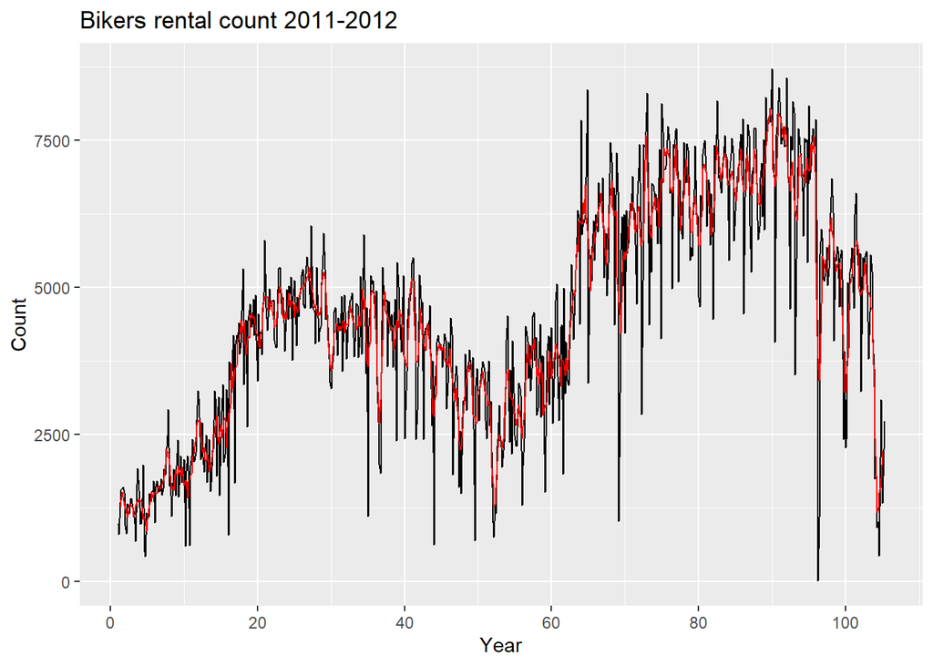

```r
#Plotting the best model to visually see the effect
autoplot(cntts, series = "Actual Counts") +
  autolayer(ma5, series = "MA(5)") +
  xlab("Year") + ylab("Count") +
  ggtitle("Bikers rental count 2011-2012") +
  scale_colour_manual(values =c("Actual Counts"="black","MA(5)"="red"),
breaks=c("Data", "5-MA"))
```

The RMSE of the different ma models are;

1. For ma5 its 707.5955
2. For ma7 its 794.9735
3. For ma11 its 868.0221
4. For ma17 its 879.68

The best model is ma5 with RMSE of 707.5955.

#### Question 8

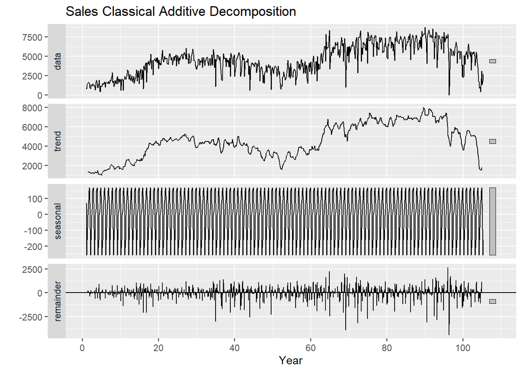

```r
dc1_classical_add <- decompose(cntts, type = "additive")
autoplot(dc1_classical_add) +
  ggtitle("Sales Classical Additive Decomposition") +
  xlab("Year")
```

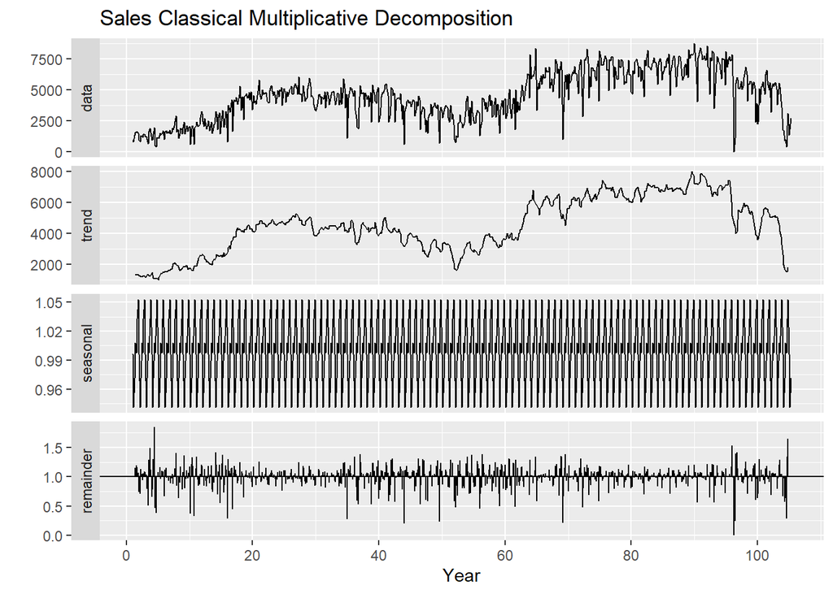

```r
#
#  Here is the multiplicative version
#
dc1_classical_mult <- decompose(cntts, type = "multiplicative")
autoplot(dc1_classical_mult) +
  ggtitle("Sales Classical Multiplicative Decomposition") +
  xlab("Year")
```

```r
#  To get the remainder part in the additive case:
#
dc1_classical_add$random
```

[output not shown]

[output cut: 136 more lines]

```r
MSE_dc1_cA <- mean((na.omit(dc1_classical_add$random))^2)
RMSE8.1 <- MSE_dc1_cA^0.5
RMSE8.1
```

```
## [1] 781.3811
```

```r
fit_cM <- dc1_classical_mult$trend *
  dc1_classical_mult$seasonal

MSE_dc1_cM <- mean((na.omit(cntts - fit_cM))^2)
RMSE8.2 <- MSE_dc1_cM^0.5
RMSE8.2
```

```
## [1] 782.5306
```

From both the classical additive and multiplicative model plot we can see that the trend had been captured very well from the data. Year 2 is higher than year 1, but both have lower bikers at the start of the year and increase in demand mid year around summer. The seasonal plot is not capturing the variability well and is not providing much insights into the seasonal effect on data.

The RMSE for the models are as below; 1. Additive model RMSE is 781.3811 2. Multiplicative model RMSE is 782.5306

Pretty close!

#### Question 9

```r
#install.packages("fpp2")
library(fpp2)

decomp_STL <- stl(cntts, s.window = 11, t.window = 7, robust = TRUE)
rem_stl <- decomp_STL$time.series[,3]
MSE_stl <- mean((rem_stl)^2)
RMSE9 <- MSE_stl^0.5
RMSE9
```

```
## [1] 750.8186
```

The RMSE of this model is 750.8186

#### Question 10

```r
all_RMSE <- cbind(RMSE3,RMSE4,RMSE6.1,RMSE6.2,RMSE6.3,RMSE6.4,RMSE7.1,RMSE7.2,
             RMSE7.3,RMSE7.4,RMSE8.1,RMSE8.2,RMSE9)

all_RMSE
```

```
##         RMSE3    RMSE4  RMSE6.1  RMSE6.2  RMSE6.3  RMSE6.4  RMSE7.1  RMSE7.2
## [1,] 1047.201 1170.851 1064.525 1341.106 1064.525 1341.106 707.5955 794.9735
##       RMSE7.3 RMSE7.4  RMSE8.1  RMSE8.2    RMSE9
## [1,] 868.0221  879.68 781.3811 782.5306 750.8186
```

The RMSE for all models are; RMSE3 RMSE4 RMSE6.1 RMSE6.2 RMSE6.3 RMSE6.4 RMSE7.1 RMSE7.2 RMSE7.3 RMSE7.4 [1,] 1047.201 1170.851 1064.525 1341.106 1064.525 1341.106 707.5955 794.9735 868.0221 879.68 RMSE8.1 RMSE8.2 RMSE9 [1,] 781.3811 782.5306 750.8186

The lowest RMSE 707.5955 is from RMSE7.1, which is moving average model with a 5-period centered moving average. This is a forecasting model, using the moving average of 5-periods to predict the biker count in coming period.

Looking at the work of the assignment, models which are able to capture the effect of season and trend as well are taking into account the overall growth in the numbers are able to provide better variability understanding in the data, that is biker rental counts. One reason why the moving average worked is that days are highly autocorrelated.